# Ending the Code/RRT

Slides by Sumit Patel, Alex Ryden, Brian Locke

## Scenario: RRT

### Unresponsive, 12h post laminectomy

HR and SpO2 ok. Pinpoint pupils, bradypneic. You give doses of naloxone without response. You..

1. Continue administering naloxone until they respond
2. Advocate for a move to the ICU
3. Defer to primary team

## Rapid Response: The Big Picture

### Possible outcomes

1. Turn into a **code blue** ([Do You Have Who/What You Need?])
2. **Go to ICU**
   - Considerations: instability, too frequent nursing care, initiation of titratable drip
   - Don’t delay - often faster and safer to get things done in ICU if dispo known (answer 2)
3. **Stay on floor**
   - Prompt stabilization and workup
   - **Always** hand off to the primary team assuming care

## Scenario: Code Blue

### A young patient has an arrest, seems like a PE.

She has been in PEA at each pulse check.

Resuscitation has been going on for 40 minutes.

When do you stop?

## How long is too long?

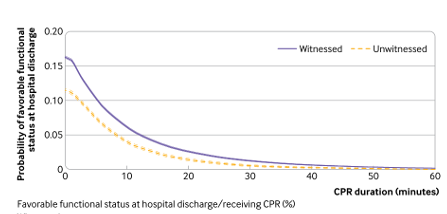

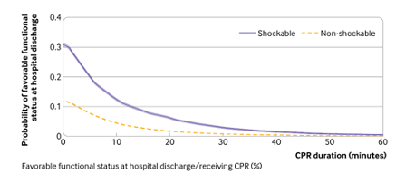

BMJ. 2024 Feb 7:384:e076019

## Things to consider:

- Pre-arrest state? more ill (esp if chronic) shorter
- Is the likely cause reversible? if so, longer
- What’s the rhythm? Shockable = good! Asystole = bad! PEA = transition state.

## The Family

[figure not shown]

Use judgement, Delegate attention, but try to include

## How to actually end an (unsuccessful) attempted resuscitation?

- “Does anyone have ideas we haven’t tried?”
- “Let’s stop CPR”
- Thank team members
- **Set a time & location to debrief** (5-15 mins)
  - feedback is the way to improve

## Summary:

### Rapid Response

- consider what’s next and don’t delay.

### Code blue

- Consider pre-arrest state, causes, and rhythms. 5-60 minutes, generally.
- Bring in family when possible
- Always debrief.

Return to Course Page